# Merged Functions

### `is.finite()`

#### Alexander Looi

This function tests for Inf or -Inf and returns TRUE if the object being evaluated is neighter Inf or -Inf.

```r
# returns True
a = 5
is.finite(10)
```

```
## [1] TRUE
```

```r
is.finite(a)
```

```
## [1] TRUE
```

```r
# returns False
is.finite(Inf)
```

```
## [1] FALSE
```

```r
is.finite(-Inf)
```

```
## [1] FALSE
```

```r
is.finite(NA)
```

```
## [1] FALSE
```

```r
# can take vectors
nums = runif(20, 1, 20)
nums[which(nums < 3)] = Inf
nums
```

```
##  [1]  8.294514  4.909840  3.636827  8.392561  6.054878 14.362629  8.749685
##  [8]  6.045720  8.618579  4.748950 16.768702 11.031767  8.507474 11.905365
## [15] 19.448469 13.352847  7.338422  7.297501 18.906263  8.241137
```

```r
# and will returns a vector of true and false. It returns true when an element is finite, and false when the cell is not.
is.finite(nums)
```

```
##  [1] TRUE TRUE TRUE TRUE TRUE TRUE TRUE TRUE TRUE TRUE TRUE TRUE TRUE TRUE
## [15] TRUE TRUE TRUE TRUE TRUE TRUE
```

```r
# character values will also return false, so be careful since an error will not be thrown.
nums[which(nums > 18)] = 'a'
is.finite(nums)
```

```
##  [1] FALSE FALSE FALSE FALSE FALSE FALSE FALSE FALSE FALSE FALSE FALSE
## [12] FALSE FALSE FALSE FALSE FALSE FALSE FALSE FALSE FALSE
```

### `is.logical()`

#### Alexander Looi

This is a function that tests if a single variable, atomic vector, matrix, or data.frame has logical variables (boolean) within it. This is regardless of the actual value of the boolean. So TRUE and FALSE variables when passed through is.logical will both return as TRUE. All other variable types will return as FALSE. Additionally vectors with multiple variables types, even if they include booleans will return FALSE since the *entire* variable is not a boolean.

```r
# case where we are evaluating single variables
g = TRUE
f = FALSE
# both return TRUE
is.logical(g); is.logical(f);
```

```
## [1] TRUE
```

```
## [1] TRUE
```

```r
# Passing other kinds of variables
n = 1
j = 0
h = 'k'
# These all return FALSE
is.logical(n); is.logical(j); is.logical(h)
```

```
## [1] FALSE
```

```
## [1] FALSE
```

```
## [1] FALSE
```

```r
# Passing a vector of TRUE FALSE
nums = runif(20)
TF_vec = c(nums > 0.5)

# Returns True
is.logical(TF_vec)
```

```
## [1] TRUE
```

```r
# Passing a vector with different kinds of variables in it.
mixed_vec = c(TF_vec, "gg", 1)
is.logical(mixed_vec)
```

```
## [1] FALSE
```

### `is.numeric`

#### Erin L. Keller

is.numeric determines whether a particular variable is numeric or not. The only input needed is the object to be tested (variable) and the output will be a logical vector with “TRUE” indicating that the variable is numeric (double or integers) and “FALSE” indicating that the variable is not numeric. It is important to note that while double is identical to numeric, however, is.double is not the same as is.numeric.

```r
x<-4
y<-"Yes"
is.numeric(x)
```

```
## [1] TRUE
```

```r
is.numeric(y)
```

```
## [1] FALSE
```

### `length`

#### Peter Clark

The **length** function provides or allows you to set the length of an object (vector,lists) in the form of an integer. Note: If the parameter is a matrix or dataframe, it returns the number of variables (columns)

**Usage**

*length(x) returns* the length of a variable as an integer

*length(x) <- value* assigns the length of an object (vector, list), where “value” is a non-negative integer. Decimals (doubles) will be rounded down

```r
# assign the length of a vector of 10, trucating at xth component
x<-1:100
length(x) <- 10
x
```

```
##  [1]  1  2  3  4  5  6  7  8  9 10
```

```r
# examine a vector is by returning its length (count)
x<-1:100
length(x)
```

```
## [1] 100
```

```r
# derive the length of two vectors to look at differences
z<-(1:30)
p<-(1:20)
length(z)-length(p)
```

```
## [1] 10
```

### `<`

#### Matthias Nevins

R funtion “<” is a *RELATIONAL OPERATION*. This binary operation can be used to compare atomic vectors.

```r
# e.g. You could assign a variable "a" to a random set of numbers and then determing which of those numbers are less than a selected value
runif(10)
```

```
##  [1] 0.15563612 0.96384166 0.00126048 0.70752621 0.63018760 0.77307804
##  [7] 0.89260688 0.51120408 0.74900107 0.92637980
```

```r
a <- runif(10)
a < .05
```

```
##  [1] FALSE FALSE FALSE FALSE  TRUE FALSE FALSE FALSE FALSE FALSE
```

```r
# Or you could create two variables and compare them
x<-5
y<-6
x<y
```

```
## [1] TRUE
```

### `<=`

#### Erin L. Keller

<= is an inequality sign that can be used to determine if the value to the left of the carat is smaller than or equal to the value to the right of the equal sign. The input arguments can be integers, atomic vectors, etc. and the ouput that is given is a logical vector where “TRUE” indicates that the inequality is correct and “FALSE” indicates that the inequality is incorrect.

```r
a<-1
b<-2
a<=b
```

```
## [1] TRUE
```

```r
b<=a
```

```
## [1] FALSE
```

### `<<-`

#### Lauren Ashlock

This function assigns a value to a variable. The arguments used are the variable and a value to be assigned to x. The difference between this function and the <- function is that <<- will search through parent environments of a package you are working in for the variable you have called. If it finds the variable in the parent environment, it will assign the value for the variable in the parent environment to the variable in your global environment. If it does not find the variable, then assignment takes place in the global environment.

```r
#example
outer_func <- function(){
   inner_func <- function(){
       a <<- 30
       print(a)
   }
   inner_func()
   print(a)
}

outer_func()
```

```
## [1] 30
## [1] 30
```

```r
print(a)
```

```
## [1] 30
```

### `list`

#### April D. Makukhov

This function is used to create a list in R, which can be made up of numeric values or even variable names.

```r
y<-list(1,2,3,4)
y
```

```
## [[1]]
## [1] 1
##
## [[2]]
## [1] 2
##
## [[3]]
## [1] 3
##
## [[4]]
## [1] 4
```

```r
x<-list('apple','orange','strawberry','kiwi')
x
```

```
## [[1]]
## [1] "apple"
##
## [[2]]
## [1] "orange"
##
## [[3]]
## [1] "strawberry"
##
## [[4]]
## [1] "kiwi"
```

```r
z<- c(x,y) # here is an example where I am combining the 2 lists I made above into one vector

z
```

```
## [[1]]
## [1] "apple"
##
## [[2]]
## [1] "orange"
##
## [[3]]
## [1] "strawberry"
##
## [[4]]
## [1] "kiwi"
##
## [[5]]
## [1] 1
##
## [[6]]
## [1] 2
##
## [[7]]
## [1] 3
##
## [[8]]
## [1] 4
```

```r
# list is also a useful function for plotting. In this example below, we are using data that is already in R (car data), and creating a vector z that is making a list made up of components 'x' and 'y', and each of those components is equal to a column of data from the cars dataset.

z <-list(x=cars[,1], y=cars[,2]) # making a list with 2 components, x and y, where x is comprised of the cars data in column 1 of the dataset, and y is comprised of the cars data in column 2 of the dataset

z
```

```
## $x
##  [1]  4  4  7  7  8  9 10 10 10 11 11 12 12 12 12 13 13 13 13 14 14 14 14
## [24] 15 15 15 16 16 17 17 17 18 18 18 18 19 19 19 20 20 20 20 20 22 23 24
## [47] 24 24 24 25
##
## $y
##  [1]   2  10   4  22  16  10  18  26  34  17  28  14  20  24  28  26  34
## [18]  34  46  26  36  60  80  20  26  54  32  40  32  40  50  42  56  76
## [35]  84  36  46  68  32  48  52  56  64  66  54  70  92  93 120  85
```

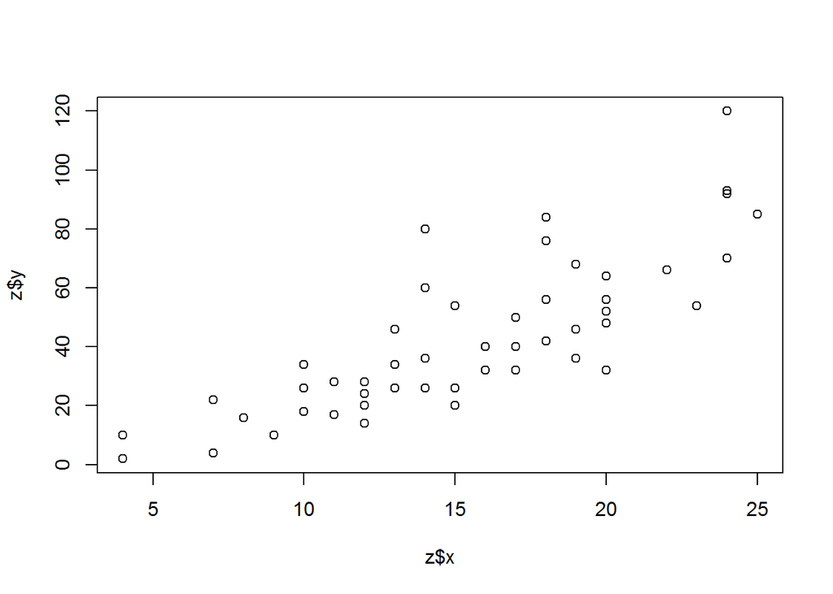

```r
plot(z) # after creating this vector z, we can see the 2 components of the list, z$x and z$y, plotted against each other
```

### `load`

#### Lauren Ashlock

- The load funtion loads R objects that have already been saved in R. The arguments for this function are the file, envir, and verbose.
- The input for the file argument is a connection or character string that gives the name of the file you want to reload.
- The envir argument designates the environment where you want the data to be loaded. This can be useful for avoiding any overwriting of existing objects with the same name in the current environment. It is best to use envir= to load the object into a different environment.
- The verbose argument designates whether or not you want item names to be printed as they load.This argument can be useful for debugging. The output of this function is a character vector of the names of objects created.
- This is particularly useful for saving and reloading .Rdata or .Rhistory files (saving your workspace) into your current environment.

```r
#example
save.image(file= "homework_6.RData") #save your workspace

#To load this make sure you are in the current working directory
#in which you saved this workspace then run the following code

load(file= "homework_6.RData")

#the default settings are to load the file in the global environment and to have verbose = False. In order to debug...

load(file= "homework_6.Rdata",verbose= TRUE)
```

```
## Loading objects:
##   model
##   varX
##   varY
##   var_names
##   mixed_vec
##   number
##   dog
##   xmatrix
##   cat
##   height.inches
##   soil
##   species
##   TF_vec
##   DF
##   bar
##   outer_func
##   c1
##   mat
##   ran_num1
##   x1
##   ran_num2
##   x2
##   ran_num3
##   baz
##   ran_num4
##   a
##   xx
##   b
##   matrix2
##   c
##   d
##   e
##   f
##   A_c
##   g
##   h
##   nums
##   j
##   k
```

[output cut: 13 more lines]

```
##   y_2
##   m2
##   myModel
##   x
##   matrix
##   y
##   dataframe
##   z
##   lst
##   num
##   x2a
##   q_c
##   zz
##   isX
##   A
```

### `log()`

#### Alex Burnham

**Description:** The log() function takes two arguemnts: a single value or a vector (x) and “base”, which allows you to choose the base of your log. By default, log() transforms the vector using the base e or natural logarithm which is defined in R as exp(1).

**Arguments:**

- x = a single value or vector
- base = the base of the log you want to use (default = exp(1) or natural log)

**Example:**

```r
# create vector of values 1 through 10:
x <- c(1:10)

# take the log (base e) of this vector x:
log(x=x)
```

```
##  [1] 0.0000000 0.6931472 1.0986123 1.3862944 1.6094379 1.7917595 1.9459101
##  [8] 2.0794415 2.1972246 2.3025851
```

```r
# take the log (base 10) of this vector x:
log(x=x, base=10)
```

```
##  [1] 0.0000000 0.3010300 0.4771213 0.6020600 0.6989700 0.7781513 0.8450980
##  [8] 0.9030900 0.9542425 1.0000000
```

This function computes the logarithm of a numeric vector, specifically computing in base 10. As we’ve learned previously in mathematics with logarithms, the input and output are switched; that is, when computing log10(x), we are actually specifying the output value ‘x’ and want to know what input value ‘y’ is the exponent with base 10 that gives us value x. Thus, we provide the ‘output’ in a sense by giving the expected value ‘x’ and are in return given the ‘input’, which is the exponent and the answer to our logarithmic computation.

```r
# We can find the value of log10(x) as follows:
log10(10)
```

```
## [1] 1
```

```r
# Here, we see the output from above is 1. This is because base 10 (which is the base we are in because we are saying 'log10' instead of just 'log') to an exponent=1 is equal to 10, the value in our ()

# Another example
log10(100) # 10^2 =100, so the output of this should be 2, as the output from a logarithic computation IS the exponent.
```

```
## [1] 2
```

```r
# If we want to take the logarithm of a different base, we would just change the 10 value and could do so as follows:
log(10, base = 3) # Here we are specificying we are in base 3, instead of 10
```

```
## [1] 2.095903
```

```r
# base 10 and base 2 are generally the more common logarithmic bases, which is why log10 and log 2 are both already functions. But, we could use the above example with base 10 and still get the same vale as log10. For example:
log(10, base = 10)
```

```
## [1] 1
```

```r
log(100, base =10)
```

```
## [1] 2
```

### `log2()`

#### Alex Burnham

**Description:** The log2() function takes a single argument (x) which is a single value or a vector and log transforms it using the base 2 logarithm.

**Arguments:**

- x = a single value or vector

**Example:**

```r
# create vector of values 1 through 10:
x <- c(1:10)

# take the log (base 2) of this vector x:
log2(x=x)
```

```
##  [1] 0.000000 1.000000 1.584963 2.000000 2.321928 2.584963 2.807355
##  [8] 3.000000 3.169925 3.321928
```

**Explanation of Example:** The output is the log (base 2) transformation of the vector x (1 through 10)

### `match`

#### Matthias Nevins

Description: The ‘match’ function returns or finds the first occurance of the first argument in the second argument. The %in% function can also be used in a similar way to return a logical vector (TRUE,FALSE)

- Usage: match(x,table,nomatch=NA_integer_,incomparables = NULL) or x %in% table
- Arguments:
  - x: a vector or NULL and represent the values to be matched
  - table: a vector or NULL and represent the values to be matched against the first argument
  - nomatch: the value to be returned if there is no match *incomparables: defines the a vector of the values that cannot be matched. FALSE=NULL

##### EXAMPLE: Using ‘match’ and ‘%in%’

- Argument 1: x=3
- Argument 2: table = 2:6

```r
match(x=3, table=2:6)
```

```
## [1] 2
```

```r
# The match function returns the first occurance of the first argument (x=3), in the second argument (table = 2:6). In this example the vector '3' is found in the second position of the table
# If you would like to return a logical vector you can use %in%
3%in%2:6 # This asks if 3 is in your table 2:6. It returns "TRUE" indictating that the first argument is indeed found in the second
```

```
## [1] TRUE
```

### `matrix`

#### Morgan W. Southgate

The matrix function creates a matrix from the given set of values.

matrix (data = NA, nrow=1, ncol=1, byrow=FALSE, dimnames = NULL)

Input:  
- data: the data vector to be converted to matrix form  
- nrow: the desired # of rows  
- ncol: the desired # of columns  
- byrow: a logical input. FALSE (default) fills matrix by columns, TRUE fills by rows.  
- dimnames: NULL or a list of of length 2 giving the row and column names, respectively. An empty list is treated as NULL and a list of length one as the row names only. NULL assigns row and column numbers automatically using matrix format of (row#,column#).

Output:  
- A matrix of the given data.

```r
# Make an atomic vector of 16 values using a sequence function
a <- 1:16

# Assign dimension names by creating a list - first four lowercase letters of alphabet will become row names, first four uppercase letters will become column names
dimnames1 <- list(letters[1:4],LETTERS[1:4])

# Assemble the atomic vector data into a matrix with 4 rows, 4 columns, and fill matrix by row
m1 <- matrix(data = a, nrow=4, ncol=4, byrow=TRUE, dimnames = dimnames1)
print(m1)
```

```
##    A  B  C  D
## a  1  2  3  4
## b  5  6  7  8
## c  9 10 11 12
## d 13 14 15 16
```

### `max()`

#### Alexander Looi

This function returns the maximum value in a vector, matrix or data frame. You can use the na.rm variable to tell the function to remove NA’s and NaN’s. If there are either of these null types in your data set and you do not specify their removal with na.rm and will return NA.

```r
# returns the largest number
nums = runif(100, 1, 100)
max(nums)
```

```
## [1] 99.68448
```

```r
# does this even if there are negatives
nums = runif(100, -100, 100)
max(nums)
```

```
## [1] 96.6014
```

```r
# watch out for NA's and Inf will return NA
nums[which(nums < -75)] = NA
max(nums)
```

```
## [1] NA
```

```r
max(nums, na.rm = T)
```

```
## [1] 96.6014
```

```r
# it interprets -Inf properly
nums[which(is.na(nums))] = -Inf
max(nums)
```

```
## [1] 96.6014
```

```r
max(nums, na.rm = T)
```

```
## [1] 96.6014
```

### `mean`

#### Melanie R. Kazenel

The `mean` function calculates the arithmetic mean of a set of values. The function takes a numeric or logical vector (or a date, date-time, or time interval object) as input, and the output of the function is the arithmetic mean of the values in the object. The output is in the form of a vector with a length of one. In addition, the `mean` function can take a complex vector as its input if specific parameters are specified.

Under default settings, the `mean` function calculates the mean of the all of the observations in an object, and any NA values in the object are not removed prior to the calcuation of the mean. To remove a particular fraction of the observations from each end of the object before the mean is computed, the “trim” argument can be added. To remove NAs from the object before the mean is computed, the “na.rm” argument can be added.

```r
### Example use of the `mean` function for a numeric vector

data <- c(4,8,10,25)

# Calculate the mean using default settings
mean(data)
```

```
## [1] 11.75
```

```r
# Trim 25% of the observations from each end of the vector, and then calculate the mean of the remaining observations.
mean(data, trim = 0.25)
```

```
## [1] 9
```

```r
### Example use of the `mean` function for a vector containing a "NA" value

data2 <- c(4,8,10,25,NA)

# Calculating the mean using default settings yields "NA"
mean(data2)
```

```
## [1] NA
```

```r
# Adding "na.rm = TRUE" removes the "NA" and then calculates the mean of the remaining observations.
mean(data2, na.rm = TRUE)
```

```
## [1] 11.75
```

### `median`

#### Erin L. Keller

To use this function, you will need two arguments:  
* x - the numeric vector from which you want the median  
* na.rm - logial value specifying whether NA values should be included or discarded in the calculation  
* na.rm = FALSE will not include NA values (default)  
* na.rm = TRUE will include NA values

```r
z <- 1:10
print(z)
```

```
##  [1]  1  2  3  4  5  6  7  8  9 10
```

```r
median(z, na.rm=FALSE)
```

```
## [1] 5.5
```

### `message`

#### Matthias Nevins

The message function generates a diagnostic message from the argument you define. These messages are not warnings or errors, but nevertheless represented as condition.

- Usage: message(…, domain = NULL, appendLF = TRUE)
- Arguments:
  - …: zero or more objects which displayed as the message. Multiple objects will be pasted together with no seperator.
  - domain: If NA, messages will not be translated
  - appendLF: Logical argument should messages

```r
message("ABC","DEFGH") # Both arguments are not separated
```

```
## ABCDEFGH
```

```r
message("good morning everyone", appendLF = FALSE) # you can display a separated message by including the whole message within a single object
```

```
## good morning everyone
```

### `min`

#### Emily Mikucki

The `min` operator returns the minimum value of all of the values in a given numeric data set/argument. The default setting includes na.rm = FALSE, so NAs will be included in the output. For example, a non numeric input will result in a NA output.

```r
min(5:1, pi) #Gives the minimum number of all of the numbers in this set
```

```
## [1] 1
```

```r
height.inches <- c(68, 65, 70, 71, 65)#Similary gives the minimum of this data set
min(height.inches)
```

```
## [1] 65
```

### `-`

#### Erin L. Keller

The - symbol, or the “minus sign” subtracts the value after the “-” from the value before the “-” as it does in arithmetic and reports the difference between those two values. The input value can be a vector, data frame, or matrix and the ouput value will be integers in a vector, matrix, or data frame (matching the input format).

```r
a<-matrix(1:6,3,2)
b<-matrix(3:8,3,2)
c<-b-a
print(c)
```

```
##      [,1] [,2]
## [1,]    2    2
## [2,]    2    2
## [3,]    2    2
```

### `%%`

#### Morgan W. Southgate

The %% function is an arithmetic operator function which gives the modulus of two arguments. This modulus operator divides the x argument by the y argument, rounds down to the nearest integer, and then finds the remainder between the (integer value * y) and the value of x. For vectors x & y where x is an integer multiple of y, the result of x mod y is 0.

x%%y

Input:  
- x,y: numeric or complex vectors or objects which can be coerced to this type

Output:  
- the difference between x and the rounded integer quotient of x/y

```r
# Assign integer values to the vectors x & y
x <- 15
y <- 4

# Find the difference between the value of x and the value of the rounded integer quotient x/y. 15/4 = 3.75, rounded down to 3. Then 3*4 = 12, and 15-12 =3.
x%%y
```

```
## [1] 3
```

```r
# When y is an integer multiple of x, x%%y = 0
12%%4
```

```
## [1] 0
```

### `*`

#### Morgan W. Southgate

The function * is an arithmetic operator function which returns the product of two numeric or complex variables or vectors. If multiplying two vectors with multiple values in each together, the multiplication function finds the consecutive products of the values in the vectors from left to right.

x*y

Input:  
- x,y : numeric or complex vectors or objects which can be coerced to numeric or complex vectors

Output:  
- the product of x and y. Logical variables are coereced to integer or numeric vectors, where FALSE = 0 and TRUE=1.

```r
# Create two vectors x1 & y1
x1 <- c(1,2,3)
y1 <- c(4,5,6)

# Find the products of the values contained in the vectors x1 and y1
x1*y1
```

```
## [1]  4 10 18
```

### `names`

#### Melanie R. Kazenel

The `names` function can be used to obtain the names associated with the elements of an object. It can also be used to assign names to the object. The function’s input is an R object, and the names associated with each element are the output.

```r
# The following vector does not have names assigned to it
z <- c(1:4)
print(z)
```

```
## [1] 1 2 3 4
```

```r
names(z)
```

[output not shown]

```r
# Assign names to the vector using the "names" function
names(z) <- c("kale", "broccoli", "cabbage", "brussels sprouts") # assign names to the vector
print(z)
```

```
##             kale         broccoli          cabbage brussels sprouts
##                1                2                3                4
```

```r
names(z) # obtain the names associated with the vector
```

```
## [1] "kale"             "broccoli"         "cabbage"
## [4] "brussels sprouts"
```

```r
# Change the name assigned to a specific element within a vector by specifying the position of the element you wish to change the name of
z <- "names<-"(z, "[<-"(names(z), 2, "collards"))
print(z)
```

```
##             kale         collards          cabbage brussels sprouts
##                1                2                3                4
```

```r
names(z)
```

```
## [1] "kale"             "collards"         "cabbage"
## [4] "brussels sprouts"
```

```r
# Remove all names associated with the vector
names(z) <- NULL
print(z)
```

```
## [1] 1 2 3 4
```

### `ncol`

#### Morgan W. Southgate

The ncol function returns the number of columns present in an atomic vector, matrix, data frame, or data array. Atomic vectors are treated as one-column matrices.

ncol(x)

Input:  
- x: a vector, matrix, array, or data frame

Output:  
- the number of columns in x

```r
# Create sequence data for infilling matrix
b <- 1:12

# Create matrix with default number of columns
m2 <- matrix(data=b)

# Tell number of columns in m
ncol(m2)
```

```
## [1] 1
```

### `nrow`

#### Erin L. Keller

nrow will report the number of rows of an array. The input arguments can be a vector, array, or data frame and the output will be a single integer reporting the number of rows.

```r
matrix<-matrix(1:10,2,5)
print(matrix)
```

```
##      [,1] [,2] [,3] [,4] [,5]
## [1,]    1    3    5    7    9
## [2,]    2    4    6    8   10
```

```r
nrow(matrix)
```

```
## [1] 2
```

### `"|" symbol or operator`

#### Alexander Looi

The pipe or bar in R denotes the “or” operator. This symbol is largely used in logical arguments where multiple booleans evaulations are given. Seperating the boolean evaluations with “|” means that only one of the evaluations have to return True for the entire evaluation to return True. All evaluations have to return False for the entire evaluation to return False. The best way to think about this is to ilterally think of it as the word “or”. So, if x is True or y is True or z is True, return True

```r
x = 8
y = 10

# this will return true since one of the evaluations will return true.
y == 10 | x > 100
```

```
## [1] TRUE
```

```r
# All evaluations have to return true have to return False for the entire evaluation to return False.
y == 11 | x >= 10
```

```
## [1] FALSE
```

### `%in%`

#### Alexander Looi

This is an operator that compares two vectors and returns to the user, a boolean vector of where in the first vector, elements are matched in the second vector. This useful when users have two vectors with similar data and they want to see which elements in the longer vector match elements in the shorter vector. This operator is particularly useful with the which() function.

```r
a = rep(letters[1:5], 20)
b = rep(letters[1:2], 4)

TF = a %in% b

TF_v = which(TF)

a[TF_v]
```

```
##  [1] "a" "b" "a" "b" "a" "b" "a" "b" "a" "b" "a" "b" "a" "b" "a" "b" "a"
## [18] "b" "a" "b" "a" "b" "a" "b" "a" "b" "a" "b" "a" "b" "a" "b" "a" "b"
## [35] "a" "b" "a" "b" "a" "b"
```

### `%/%`

#### Emily Mikucki

```r
x <- -1:12
x %/% 5
```

```
##  [1] -1  0  0  0  0  0  1  1  1  1  1  2  2  2
```

### `+`

#### Erin L. Keller

```r
a<-4.4
b<-1.2
c<-a+b
print(c)
```

```
## [1] 5.6
```

```r
d<-1:2
e<-d+1
print(e)
```

```
## [1] 2 3
```

### `pmax`

#### April D. Makukhov

The ‘p’ in pmax stands for ‘parallel’. This function outputs the parallel maxima of values inputed. Essentially, this means you can take one or more vectors and, with pmax, create a single vector that has only the maxima between the multiple vectors. pmax allows you to find the maximum values among multiple vectors and receive an output with those maximum values.

```r
# Making 2 vectors, x and y, of the same length
x <- c(1,5,7,9,3,15,37,128,4)
y <- c(2,8,12,54,207,95,73,122,62)
pmax(x,y) # this gives a single output vector that contains the maximum values of these two vectors with respect to position. For example, the first value of the pmax vector is 2 because '2' in the first position of vector y is greater than '1' in the first position of vector x.
```

```
## [1]   2   8  12  54 207  95  73 128  62
```

### `pmin()`

#### Alexander Looi

Not to be confused with the min() function. pmin() returns the min values of *parallel* input values. Parallel in this case means corresponding element positions of multiple vectors. For example, consider vectors a = c(“a”, “b”, “c”, “d”) and b = c(1, 2, 3, 4). The first elements of vectors a and b (“a” and 1) considered to be parallel elements. You can use the na.rm variable to tell the function to remove NA’s and NaN’s. If there are either of these null types in your data set and you do not specify their removal with na.rm the NA will be chosen as the “min” value.

```r
ran_num1 = c(1, 20, 16)
ran_num2 = c(4, 11, 6)
ran_num3 = c(7, 8, 22)
ran_num4 = c(10, 11, 12)
# should return c(1, 8, 6)
pmin(ran_num1, ran_num2, ran_num3, ran_num4)
```

```
## [1] 1 8 6
```

```r
# An NA in the data set
ran_num1 = c(1, 20, 16)
ran_num2 = c(4, 11, 6)
ran_num3 = c(7, NA, 22)
ran_num4 = c(10, 11, 12)
pmin(ran_num1, ran_num2, ran_num3, ran_num4)
```

```
## [1]  1 NA  6
```

```r
# An NA in the data set but na.rm is used
ran_num1 = c(1, 20, 16)
ran_num2 = c(4, 11, 6)
ran_num3 = c(7, NA, 22)
ran_num4 = c(10, 11, 12)
pmin(ran_num1, ran_num2, ran_num3, ran_num4, na.rm = T)
```

```
## [1]  1 11  6
```

```r
# careful with evaluating matrices! It will look at parallel elements between matrices.
ran_num1 = c(1, 20, 16)
ran_num2 = c(4, 11, 6)
ran_num3 = c(7, 8, 22)
ran_num4 = c(10, 11, 12)
a = matrix(c(ran_num1, ran_num2, ran_num4), 3, 3)
b = matrix(c(ran_num2, ran_num4, ran_num1), 3, 3)
pmin(a, b)
```

```
##      [,1] [,2] [,3]
## [1,]    1    4    1
## [2,]   11   11   11
## [3,]    6    6   12
```

```r
# works for dataframes as well (should have the same result as the above matrix.
a = data.frame(ran_num1, ran_num2, ran_num4)
b = data.frame(ran_num2, ran_num4, ran_num1)
pmin(a, b)
```

```
##   ran_num1 ran_num2 ran_num4
## 1        1        4        1
## 2       11       11       11
## 3        6        6       12
```

```r
# careful you don't use characters
a = data.frame(ran_num1, c('a', 'b', 'c'), ran_num4)
b = data.frame(ran_num2, ran_num4, ran_num1)
pmin(a, b)
```

```
##   ran_num1 c..a....b....c.. ran_num4
## 1        1                a        1
## 2       11                b       11
## 3        6                c       12
```

```r
# even if the columns are aligned to the correct variable type
a = data.frame(ran_num1, c('a', 'b', 'c'), ran_num4, stringsAsFactors = F)
b = data.frame(ran_num2, c('g', 'g', 'h'), ran_num1, stringsAsFactors = F)
pmin(a, b)
```

```
##   ran_num1 c..a....b....c.. ran_num4
## 1        1                a        1
## 2       11                b       11
## 3        6                c       12
```

### `print`

#### Erin L. Keller

print is a function that displays the ouput of the input object while making the arguments invisible. Typically, this function is used to visualize data and the same result can be achieved by simply typing the variable name. For this function, inputs of any form can be used; however, some forms may require additional information including: * quote - a logical object used to indicate whether strings should be printed * max.levels - an integer indicating how many levels for a factor should be printed. The detault is NULL which will print on one line of a specified width * digits - the minimum number of significant digits * na.print - a character string which indicates NA values in the output * zero.print - this character can specify if 0’s should be included (some people prefer looking at decimals without the 0) * justify - a character that indicates whether strings should be right- or left-justified or not justified * useSource - this logical indicates whether an internally stored source should be present when printing (keep.source=TRUE if in use)

print.factor allows further customization whiel print.table allows further customization for tables. The output of this function will be the form of the input object.

```r
Rainfall <- matrix(c(1.2,2.4,4.2,6.3,8.9,11.1,12.2,10.7),4,2)
colnames(Rainfall)<-c("Desert","Deciduous")
rownames(Rainfall)<-c("December","February","March","April")
print(Rainfall)
```

```
##          Desert Deciduous
## December    1.2       8.9
## February    2.4      11.1
## March       4.2      12.2
## April       6.3      10.7
```

### `prod`

#### Emily Mikucki

The `prod` function is a multiplier operator. It returns the multiplication results of all the values present in the arguments you create (… represents numeric, complex or logical vectors). The default setting includes na.rm = FALSE where NAs are still included in your output.This is an easy way to multiply more than two variables at a time, rather than just using `*`.

```r
x <- c(3.2,5,4.3) #You can create a list of values and multiply them this way.
prod(x)
```

```
## [1] 68.8
```

```r
prod(4:6) #Or you can create a series and multiply them directly like this
```

```
## [1] 120
```

### `?`

#### Morgan W. Southgate

The documentation shortcut ? provides access to documentation and help on an unknown function. Available for use only in the console.

?function.name

Input:  
- name of the function

Output:  
- documentation and user help displayed in the help console (lower R)

```r
?mean
```

```
## starting httpd help server ...
```

```
##  done
```

### `range()`

#### Alex Burnham

**Description:** range returns a vector containing the minimum and maximum of all the given arguments.

**Arguments:**

- first value is any numeric or character object
- na.rm = TRUE or FALSE (if TRUE NAs are omitted)

**Example:**

```r
# create vector of values 1 through 10:
x <- c(1:10)

# find the range in vector x
range(x)
```

```
## [1]  1 10
```

**Explanation of Example:** The smallest value “1” and largest “10” are given.

### `rbind`

#### Lauren Ashlock

- rbind takes a sequence of vector, matrix, or data-frame areguments and combines them by rows.
- Arguments: are vectors or matrices, that can be given as named arguments.
- deparse.level is an integer argument that controls the construction of labels in the case of non-matrix-like arguments. The default is 0, which constructs no labels. 1 or 2 constructs labels from the argument names
- make.row.names is an argument that is only used when binding data frames. It is a logical argument that indicates if unique and valid row.names should be constructed fromt the arguments.
- stringsAsFactors is a logical argument that is passed to as.data.frame. This only has an effect when the arguments contain a non-data.frame) character

```r
#example

m<- rbind(1,1:7)
m
```

```
##      [,1] [,2] [,3] [,4] [,5] [,6] [,7]
## [1,]    1    1    1    1    1    1    1
## [2,]    1    2    3    4    5    6    7
```

```r
m <- rbind(m, 8:14)
m
```

```
##      [,1] [,2] [,3] [,4] [,5] [,6] [,7]
## [1,]    1    1    1    1    1    1    1
## [2,]    1    2    3    4    5    6    7
## [3,]    8    9   10   11   12   13   14
```

```r
#deparse.level argument

dd<- 10
rbind(1:4, c=2, "a++"=10, deparse.level =0) #this names the rows of the middle two arguments
```

```
##     [,1] [,2] [,3] [,4]
##        1    2    3    4
## c      2    2    2    2
## a++   10   10   10   10
```

```r
rbind(1:4, c=2, "a++"=10, dd, deparse.level=1) #this names the last three arguments (this is the default setting)
```

```
##     [,1] [,2] [,3] [,4]
##        1    2    3    4
## c      2    2    2    2
## a++   10   10   10   10
## dd    10   10   10   10
```

```r
rbind(1:4, c=2, "a++" =10, dd, deparse.level=2) #takes the names from each element
```

```
##     [,1] [,2] [,3] [,4]
## 1:4    1    2    3    4
## c      2    2    2    2
## a++   10   10   10   10
## dd    10   10   10   10
```

### `readLines`

#### Melanie R. Kazenel

The `readLines` function can be used to read text or data into R that is not formatted in a way conducive to being read in using a function such as `read.csv` or `read.table`. For instance, `readLines` can be used to read in unformatted text. The input for the function is a URL or file. The output is a vector in which each element corresponds to a line in the input file.

The “n=” argument can be used to specify the number of lines you want to be read in; the default value is -1 and means that all lines will be read in. The “ok” argument can be used to specify whether a warning message should come up if the end of the file is reached before the number of lines specified in the “n=” argument is reached; the default is TRUE. The “encoding” argument can be used to specify the type of encoding used in the document; the default is “unknown.” The “skipNul” argument can be used to specify whether nulls in the dataset should be skipped rather than read in; the default is FALSE. The “warn” argument can be added to specify whether certain warning messages should come up; the default is TRUE.

```r
# Read all of the text from a webpage into R
z <- readLines("https://gotellilab.github.io/Bio381/CourseMaterials/CourseSyllabus.html")
summary(z)
```

```
##    Length     Class      Mode
##       284 character character
```

```r
# Read the first 5 lines from a webpage into R
z <- readLines("https://gotellilab.github.io/Bio381/CourseMaterials/CourseSyllabus.html", n = 5L)
summary(z)
```

```
##    Length     Class      Mode
##         5 character character
```

```r
print(z)
```

```
## [1] "<!DOCTYPE html>"
## [2] ""
## [3] "<html xmlns=\"http://www.w3.org/1999/xhtml\">"
## [4] ""
## [5] "<head>"
```

### `readRDS`

#### Lauren Ashlock

This function is used to write a single R object to a file, and to restore that object. Arguments: - object: R object to be written to a file  
- file: a connection or the name of the file where the R object is saved to or read from  
- ascii: A logical. If TRUE or NA, an ASCII representation is written. The default for this argument is FALSE. This results in a binary representation.  
- version: This argument will only be relevant with versions newer than the default version (2).  
- compress: A logical stating whether or not you want your saved object to be compressed. The default for this argument is TRUE.  
- refhook: This is a hook function for handling reference objects. The default for this argument is NULL.

```r
#example

##save a single object to file
copepod<-10
saveRDS(object=copepod, file="copepod.rds")
##restore it under a different name
copepod2 <- readRDS(file="copepod.rds")
identical(copepod, copepod2)
```

```
## [1] TRUE
```